# Лабораторная работа №13

Настройка NFS

Цыкунова Екатерина Михайловна

1132246732@rudn.ru

Российский университет дружбы народов

# Цели и задачи работы

## Цель лабораторной работы

Целью данной работы является приобретение практических навыков установки и настройки сервера NFSv4, организации доступа к общим сетевым ресурсам, подключения каталогов веб-сервера и пользователей к дереву NFS, а также автоматизации настройки NFS-сервера и клиента средствами Vagrant.

## Задачи лабораторной работы

- установить и настроить сервер NFSv4;
- настроить межсетевой экран и права доступа к общим ресурсам;
- подключить удалённый ресурс NFS на клиенте;
- подключить каталог веб-сервера к дереву NFS;
- организовать удалённый доступ к пользовательскому каталогу;

# Процесс выполнения лабораторной работы

## Устанавливаю NFS и создаю общий каталог на сервере

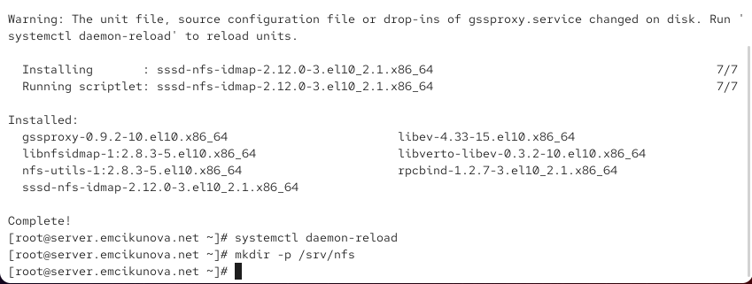

Установка пакета nfs-utils и создание корневого каталога /srv/nfs

## Настраиваю экспорт корневого каталога NFS

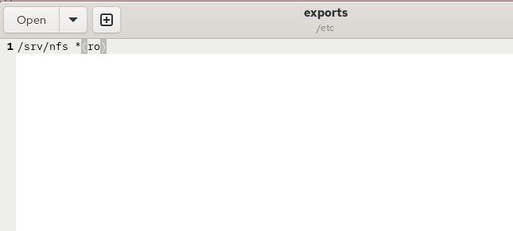

Добавление записи /srv/nfs *(ro) в конфигурационный файл /etc/exports

## Настраиваю SELinux и запускаю NFS-сервер

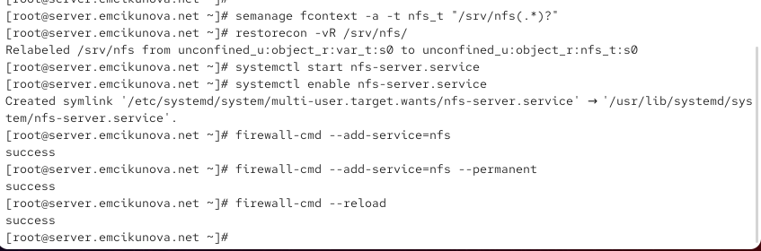

Назначение контекста nfs_t, запуск службы nfs-server и настройка межсетевого экрана

## Устанавливаю NFS на клиенте и проверяю подключение

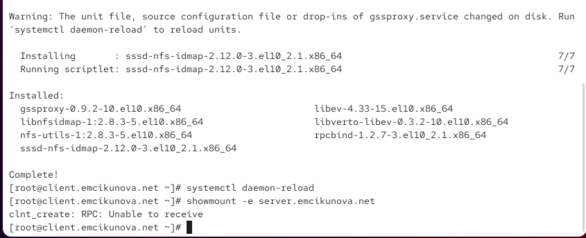

Установка nfs-utils и проверка доступных ресурсов командой showmount

## Проверяю TCP-соединения служб RPC

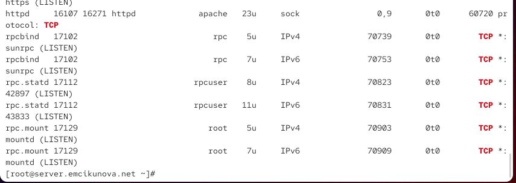

Просмотр сетевых соединений процессов rpcbind, rpc.statd и rpc.mountd

## Проверяю UDP-соединения служб RPC

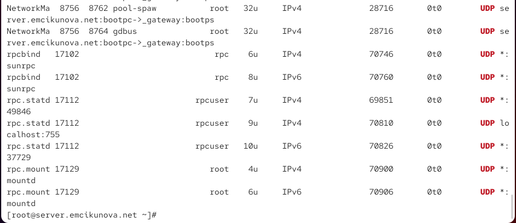

Просмотр UDP-сокетов служб RPC на NFS-сервере

## Настраиваю межсетевой экран для работы RPC

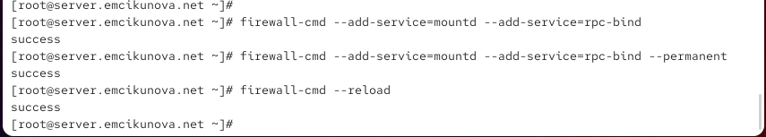

Добавление служб mountd и rpc-bind в настройки firewalld

## Проверяю доступность экспортируемых ресурсов NFS

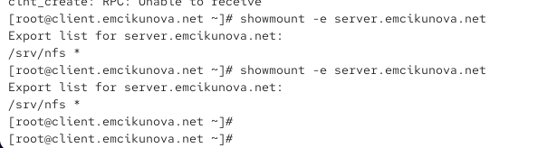

Успешное получение списка общих каталогов командой showmount -e

## Настраиваю автоматическое монтирование NFS на клиенте

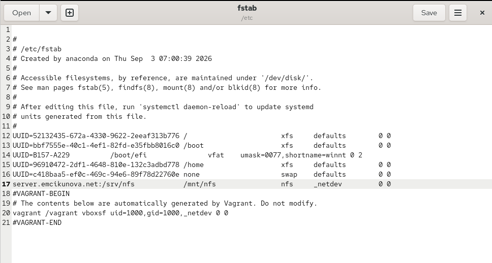

Добавление записи для подключения удалённого ресурса в файл /etc/fstab

## Проверяю подключение NFSv4 на клиенте

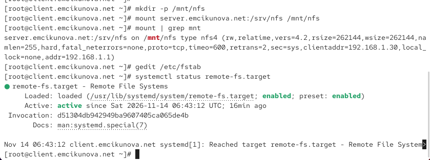

Просмотр параметров монтирования и состояния remote-fs.target

## Повторно проверяю монтирование удалённого ресурса

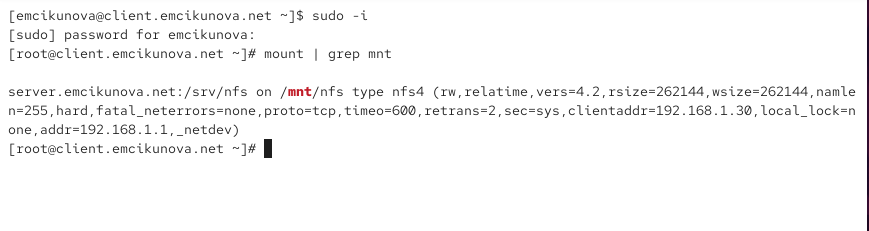

Проверка подключения сервера NFS к каталогу /mnt/nfs

## Подключаю каталог веб-сервера к дереву NFS

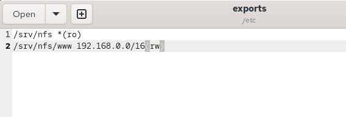

Создание каталога /srv/nfs/www и настройка его экспорта с правами чтения и записи

## Настраиваю постоянное монтирование каталога веб-сервера

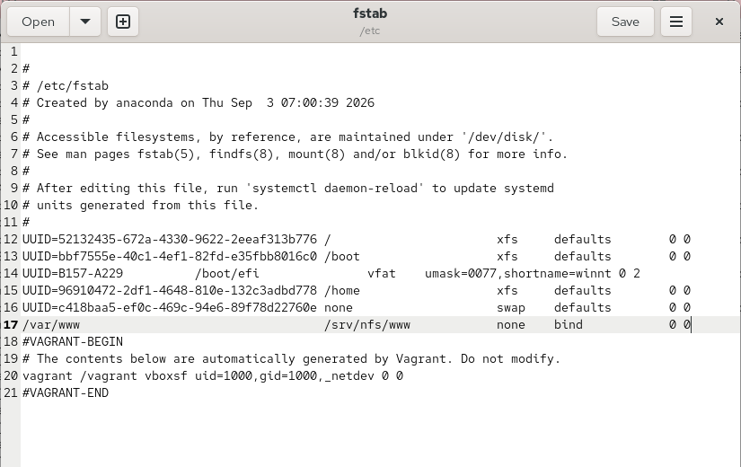

Добавление bind-монтирования каталога /var/www в файл /etc/fstab

## Применяю настройки экспорта каталога веб-сервера

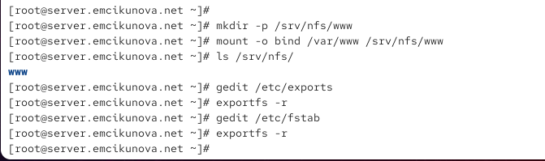

Bind-монтирование веб-каталога и обновление конфигурации командой exportfs -r

## Проверяю доступность веб-каталога на клиенте

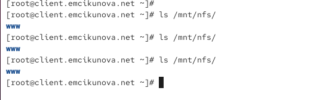

Просмотр содержимого общего каталога /mnt/nfs и проверка наличия директории www

## Создаю пользовательский каталог для удалённой работы

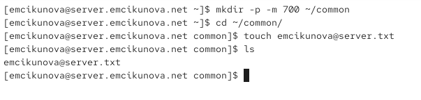

Создание каталога common с правами 700 и файла emcikunova@server.txt

## Подключаю пользовательский каталог к дереву NFS

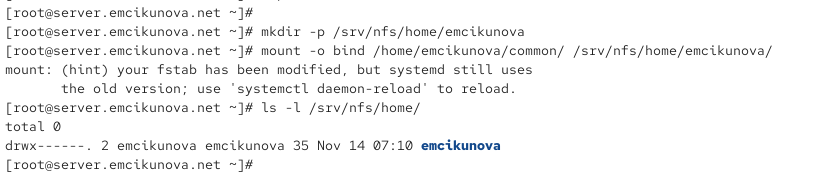

Bind-монтирование каталога common и проверка прав доступа пользователя emcikunova

## Настраиваю экспорт пользовательского каталога

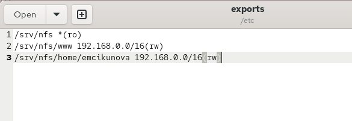

Добавление каталога /srv/nfs/home/emcikunova в файл /etc/exports

## Настраиваю постоянное монтирование пользовательского каталога

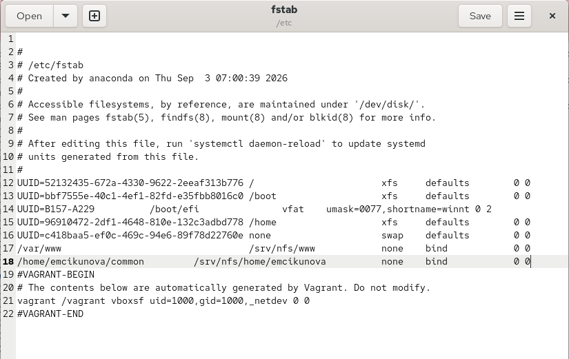

Добавление bind-монтирования пользовательского каталога в /etc/fstab

## Проверяю права доступа к пользовательскому каталогу

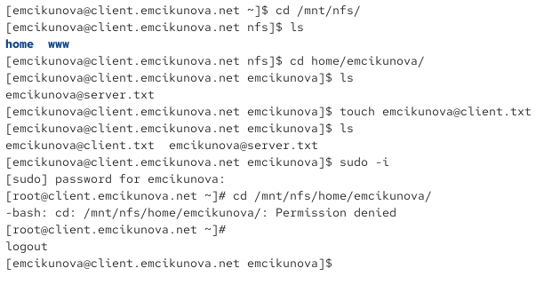

Создание файла emcikunova@client.txt на клиенте и проверка ограничений доступа для root

## Проверяю изменения пользовательского каталога на сервере

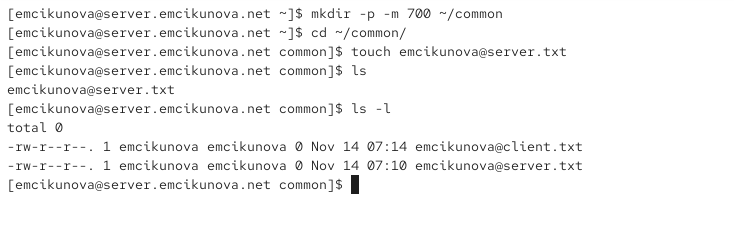

Проверка появления файла emcikunova@client.txt в каталоге common на сервере

## Подготавливаю конфигурацию NFS-сервера для Vagrant

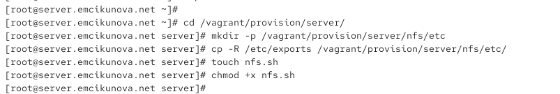

Создание каталога nfs, копирование файла exports и создание исполняемого скрипта nfs.sh

## Создаю скрипт автоматической настройки NFS-сервера

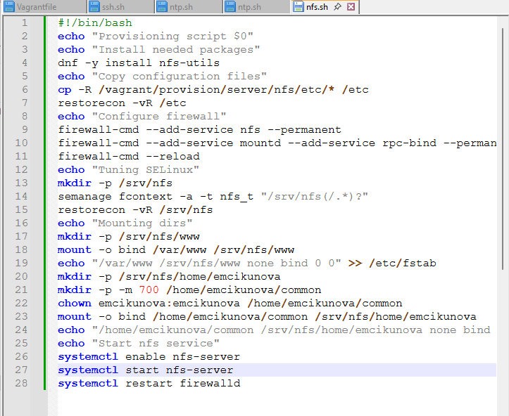

Добавление команд установки NFS, настройки SELinux, межсетевого экрана и монтирования каталогов

## Создаю исполняемый скрипт настройки NFS-клиента

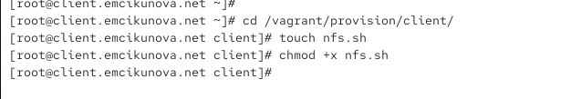

Создание файла nfs.sh в каталоге /vagrant/provision/client и назначение прав выполнения

## Настраиваю автоматическое подключение NFS на клиенте

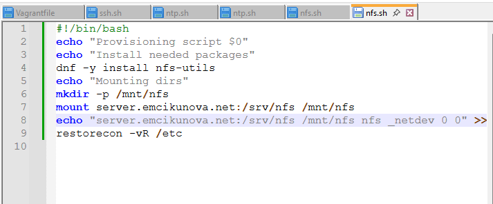

Добавление команд установки nfs-utils, подключения удалённого ресурса и изменения /etc/fstab

# Результаты лабораторной работы

## Вывод

В ходе лабораторной работы я установила и настроила сервер NFSv4 на виртуальной машине `server.emcikunova.net`. Создала общий каталог `/srv/nfs`, настроила экспорт сетевых ресурсов, права доступа, контексты безопасности SELinux и правила межсетевого экрана.

На виртуальной машине `client.emcikunova.net` подключила удалённый ресурс NFS и настроила его автоматическое монтирование через `/etc/fstab`. Проверила доступность общих каталогов и работу протокола NFSv4.2.

Подключила к дереву NFS каталог веб-сервера `/var/www` и пользовательский каталог `/home/emcikunova/common`. Проверила возможность создания файлов с клиентской машины и ограничения доступа для удалённого суперпользователя.

Создала скрипты `nfs.sh` для автоматизации настройки NFS-сервера и клиента средствами Vagrant.